# IE 423 PROJECT FIRST SUBMISSION

## Part 1

### 1)

```r
install.packages("jpeg")
library(jpeg)
```

We installed required "jpeg" package.

```r
img <- readJPEG("C:/Users/cillop/Desktop/suet423.jpeg" , native=FALSE)
```

We read the image into a variable.

### 2)

```r
str(img)
```

```
 num [1:512, 1:512, 1:3] 0.557 0.557 0.557 0.561 0.561 ...
```

```r
class(img)
```

'array'

The variable is a three-dimensional array. The size of the array is 512x512x3.

#### a)

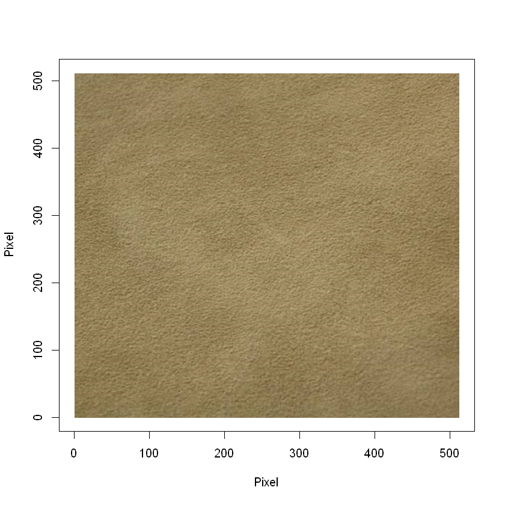

```r
plot(NA,xlab="Pixel",ylab="Pixel",xlim=c(0,nrow(img)),ylim=c(0,ncol(img)))
rasterImage(img,0,0,nrow(img),ncol(img))
```

We displayed the image using "rasterImage" function.

#### b)

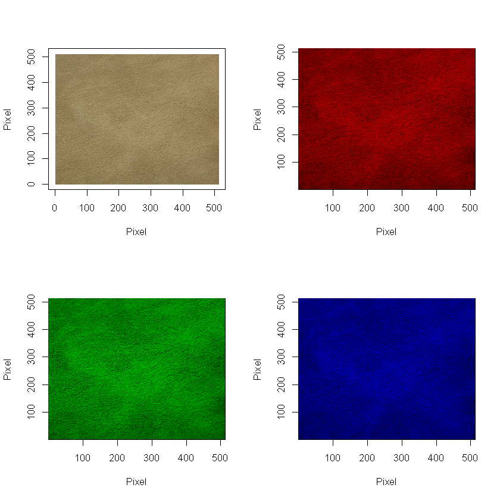

```r
par(mfrow=c(2,2))
r<-apply(img[,,1],2,rev)
g<-apply(img[,,2],2,rev)
b<-apply(img[,,3],2,rev)

plot(NA, xlab="Pixel", ylab="Pixel",xlim=c(0,nrow(img)),ylim=c(0,ncol(img)))
rasterImage(img,0,0,nrow(img),ncol(img))
image(1:ncol(r),1:nrow(r), as.matrix(t(r)), col=rgb(0:255,0,0,max=255),xlab="Pixel",ylab="Pixel")
image(1:ncol(g),1:nrow(g), as.matrix(t(g)), col=rgb(0,0:255,0,max=255),xlab="Pixel",ylab="Pixel")
image(1:ncol(b),1:nrow(b), as.matrix(t(b)), col=rgb(0,0,0:255,max=255),xlab="Pixel",ylab="Pixel")
```

### 3)

```
 num [1:512] 0.562 0.562 0.565 0.566 0.563 ...
 num [1:512] 0.49 0.49 0.494 0.494 0.491 ...
 num [1:512] 0.328 0.328 0.331 0.331 0.328 ...
```

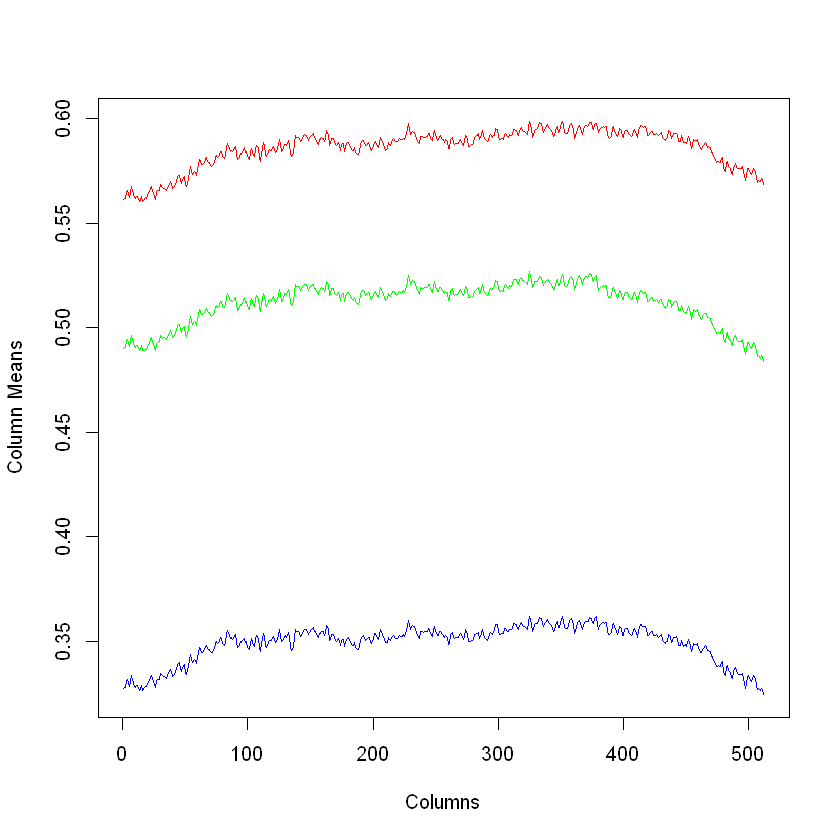

```r
kirmizi<- colMeans(img[,,1])
x<-c(1:512)
str(kirmizi)
yesil<- colMeans(img[,,2])
str(yesil)
mavi<- colMeans(img[,,3])
str(mavi)
plot(x,kirmizi,type="l",col="red",ylab="Column Means",xlab="Columns",ylim=range( c(kirmizi,yesil,mavi) ))
lines(x,yesil,type="l",col="green")
lines(x,mavi,type="l",col="blue")
```

For each channel, we took the average of the columns and plot these values on a single plot.

### 4)

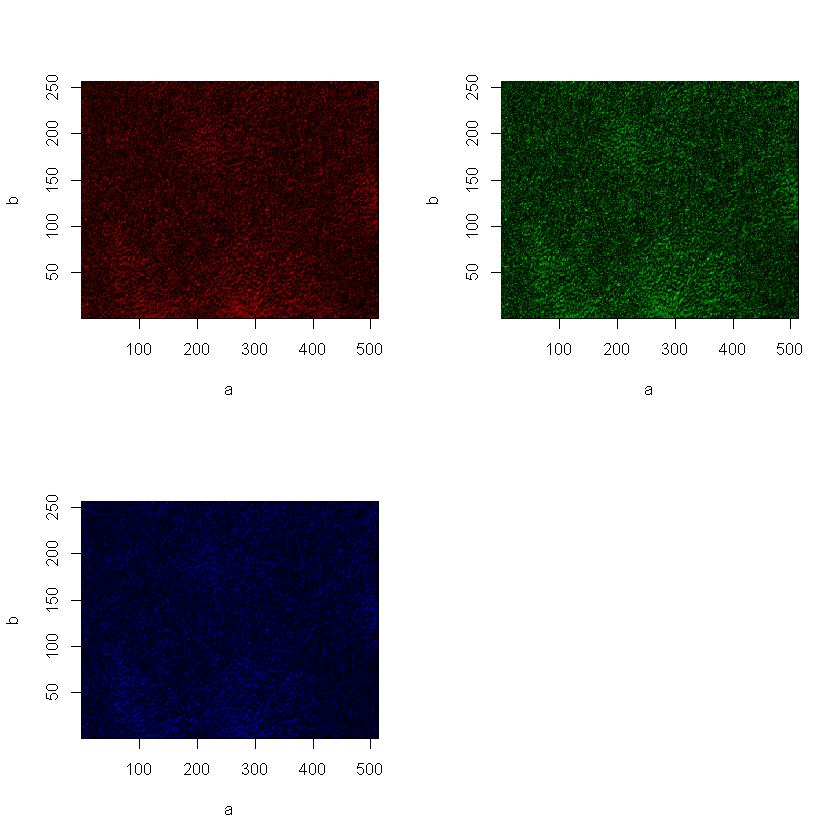

```r
par(mfrow=c(2,2))
r<-apply(img[,,1],2,rev)
g<-apply(img[,,2],2,rev)
b<-apply(img[,,3],2,rev)


half1r<-r[c(1:256),]
half2r<-r[c(257:512),]
half1g<-g[c(1:256),]
half2g<-g[c(257:512),]
half1b<-b[c(1:256),]
half2b<-b[c(257:512),]

r<-abs(half2r-half1r)

g<-abs(half2g-half1g)

b<-abs(half2b-half1b)


image(1:ncol(r),1:nrow(r), as.matrix(t(r)), col=rgb(0:255,0,0,max=255),xlab="a",ylab="b")
image(1:ncol(g),1:nrow(g), as.matrix(t(g)), col=rgb(0,0:255,0,max=255),xlab="a",ylab="b")
image(1:ncol(b),1:nrow(b), as.matrix(t(b)), col=rgb(0,0,0:255,max=255),xlab="a",ylab="b")
```

### 5)

```r
install.packages("BiocManager")
BiocManager::install("EBImage")
library(EBImage)
```

We installed "EBImage" package to perform median filtering operations. By using "medianFilter" function, we can apply median filtering to our image.

#### a)

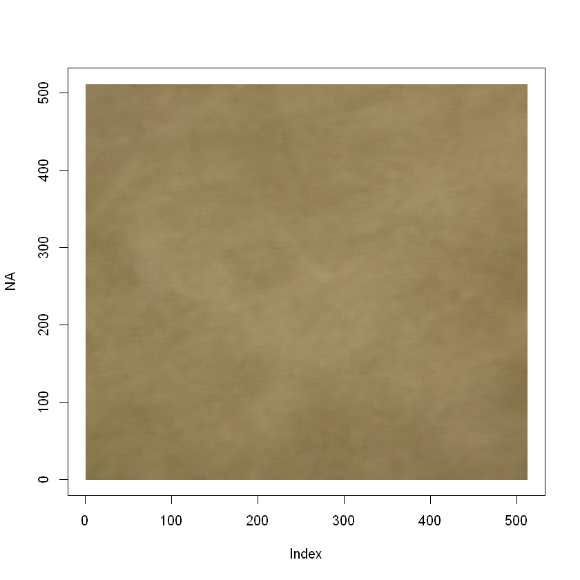

```r
img5 <- medianFilter(img,5)
plot(NA,xlim=c(0,nrow(img5)),ylim=c(0,ncol(img5)))
rasterImage(img5,0,0,nrow(img5),ncol(img5))
```

We applied median filtering to our image with 5x5 window size.

#### b)

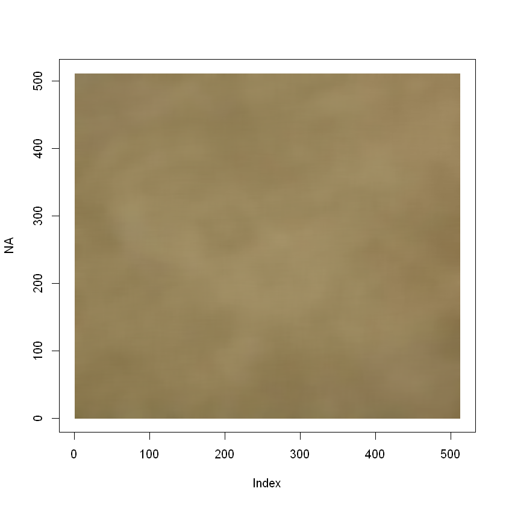

```r
img11 <- medianFilter(img,11)
plot(NA,xlim=c(0,nrow(img11)),ylim=c(0,ncol(img11)))
rasterImage(img11,0,0,nrow(img11),ncol(img11))
```

We applied median filtering to our image with 11x11 window size.

#### c)

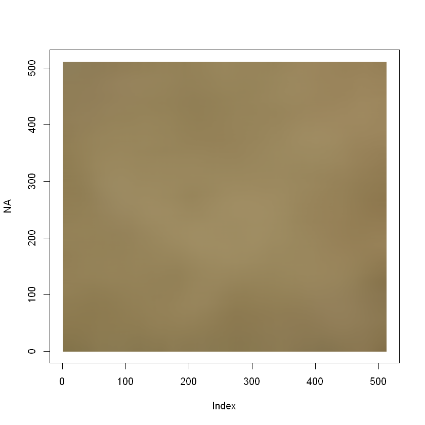

```r
img31 <- medianFilter(img,31)
plot(NA,xlim=c(0,nrow(img31)),ylim=c(0,ncol(img31)))
rasterImage(img31,0,0,nrow(img31),ncol(img31))
```

Median filtering is a good noise-reduction technique. However it has a very significant drawback. We observed that in median filtering the clarity of the image decreases as the window size increases. The reason is the median values are getting closer to each other at same time. Therefore, we obtain very smooth and almost monochrome images.

## Part 2

```r
imggray <- readJPEG("C:/Users/cillop/Desktop/suetgray.jpg" , native=FALSE)
```

We read the new image into a new variable.

### 1)

```r
install.packages("fitdistrplus")
library("fitdistrplus")
```

We installed "fitdistrplus" package to propose a pixel value distribution. By using "fitdist" function, we could draw the histogram of the pixel values, Q-Q plot, empirical and theoretical CDFs and P-P plot.

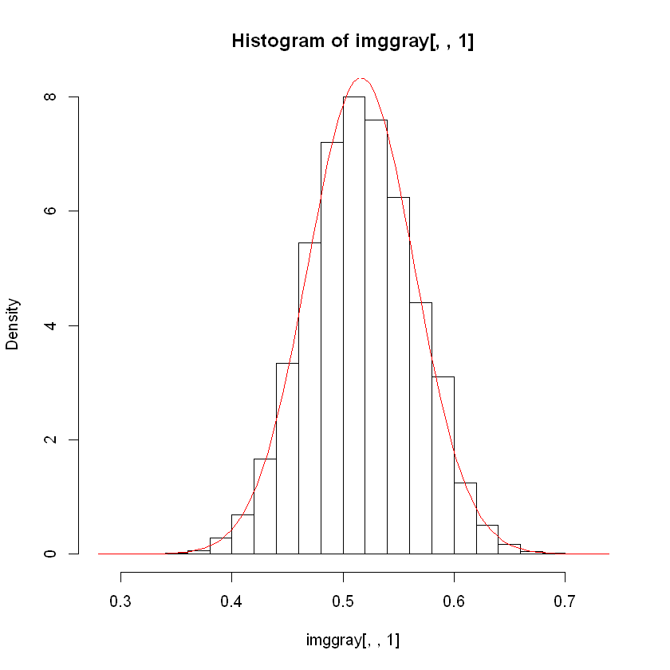

```r
hist(imggray[,,1],breaks=30,freq=FALSE)
x<-seq(0,1,by=0.01)
curve(dnorm(x,mean(imggray[,,1]),sd(imggray[,,1])), add=TRUE,col="red")
```

We drew the histogram of the pixel values and a normal distribution curve (using standard deviation and mean of the pixel values) on a single graph.

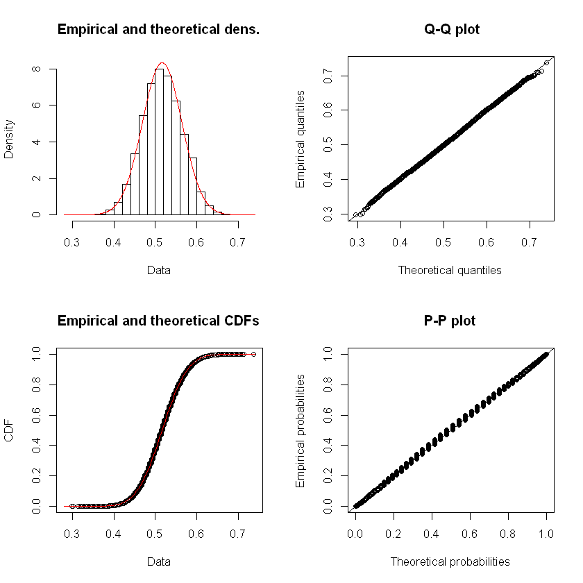

```r
ft <- fitdist(as.numeric(imggray[,,1]), distr = "norm" )
plot(ft)
```

We suppose that pixel values have normal distribution. Because, histogram is bell-shaped; Q-Q plot, empirical and theoretical CDFs and P-P plot are well fitted.

```r
mysample<-sample(length(imggray[,,1]),512,replace=TRUE)
shapiro.test(imggray[,,1][mysample])
```

```
	Shapiro-Wilk normality test

data:  imggray[, , 1][mysample]
W = 0.9967, p-value = 0.3814
```

To double-check, we applied Shapiro-Wilk Normality Test and obtained a p-value higher than 0.05. Therefore, we can say that pixel values are normally distributed.

### 2)

```r
mean(imggray[,,1])
sd(imggray[,,1])
```

0.516394312241498

0.0478538092055305

Firstly, we estimated the mean by calculating sample mean and the variance by calculating sample variance. It is known that sample mean and sample variance are unbiased estimators of mean and variance.

```r
mean_mle<-function(array)
{
        mean(array)
}

sd_mle<-function(array)
{
        sqrt(sum((array-mean_mle(array))^2)/(length(array)))
}

mean_mle(imggray[,,1])
sd_mle(imggray[,,1])
```

0.516394312241498

0.0478537179315459

MLE is another way to estimate those parameters. We created two functions to calculate mean and standard deviation via MLE approach. Here are the formulas:

$$\hat{\mu}_{MLE} = \dfrac{1}{n}\sum\limits_{i=1}^n x_i $$$$ $$$$\hat{\sigma}_{MLE} = \sqrt{\dfrac{1}{n}\sum\limits_{i=1}^n (x_i-\mu)^2}$$

As it can be seen above, mean estimation of MLE approach and sample mean are equal. Besides, standart deviation estimates are quite close. For the sake of simplicity, we decided to use sample variance as the estimator of standart deviation.

### 3)

```r
imgdata <- imggray[,,1]
imgdata[imgdata<=quantile(imggray[,,1],0.0005)] <- 0
imgdata[imgdata>=quantile(imggray[,,1],0.9995)] <- 0
```

We changed the values of the pixels that are out of the 0.001 probability limits to zero.

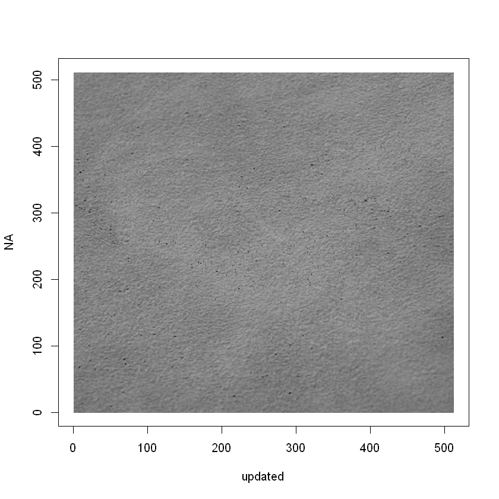

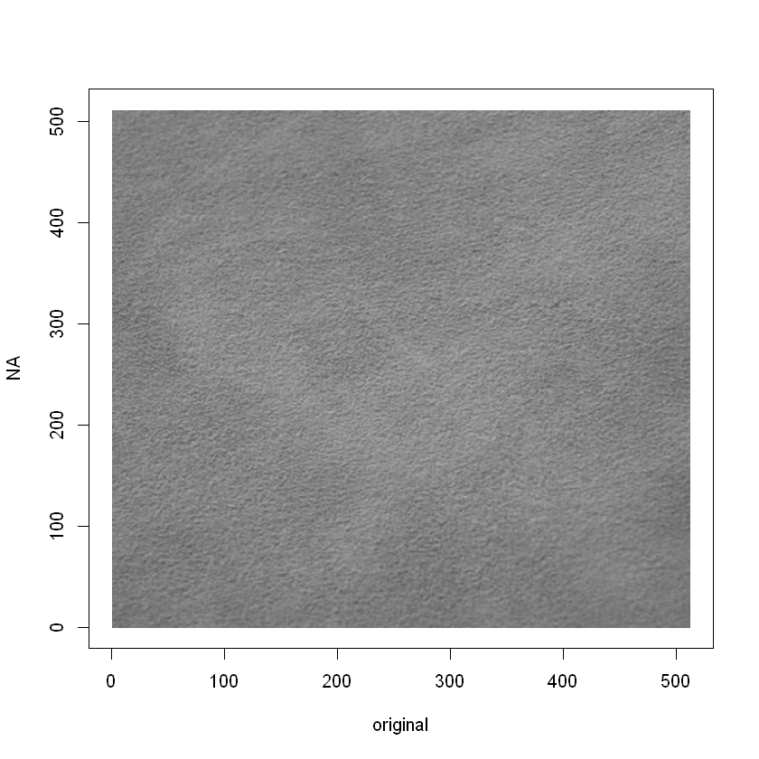

```r
par(mfrow=c(1,1))
plot(NA,xlim=c(0,nrow(imgdata)),ylim=c(0,ncol(imgdata)),xlab="updated")
rasterImage(imgdata,0,0,nrow(imgdata),ncol(imgdata))
plot(NA,xlim=c(0,nrow(imggray)),ylim=c(0,ncol(imggray)),xlab="original")
rasterImage(imggray,0,0,nrow(img),ncol(imggray))
```

We displayed the updated image and the original image.

In the updated image, the outlier whitest and blackest pixels were converted to pure black pixels. Since our original image mostly consists of moderate gray pixels and extreme values are not really extreme in the original image, we could see the significant effects of this operation. The reason is left and right tails of the pixel values' normal distribution graph are very short. For example, in the original image there is no pure black pixel. But after the operation, we can see some black dots in the updated image.

### 4)

```r
imgwindow<-matrix(0,nrow=512,ncol=512)
imgdata2<-imggray[,,1]
for (k in c(1:10)){
    for (j in c(1:10)){
    patch <- imgdata2[(1+(k-1)*51):(k*51),(1+(j-1)*51):(j*51)]
    q005<-quantile(patch, .0005)
    q995<-quantile(patch, .9995)
    patch[patch<=q005] <- 0
    patch[patch>=q995] <- 0
    imgwindow[(1+(k-1)*51):(k*51),(1+(j-1)*51):(j*51)]<- patch
        }
}
```

We used two for loops to create 51x51 patches and we applied the same procedure in the 3rd question to those patches. Lastly, we merged them to obtain the updated (patched) image

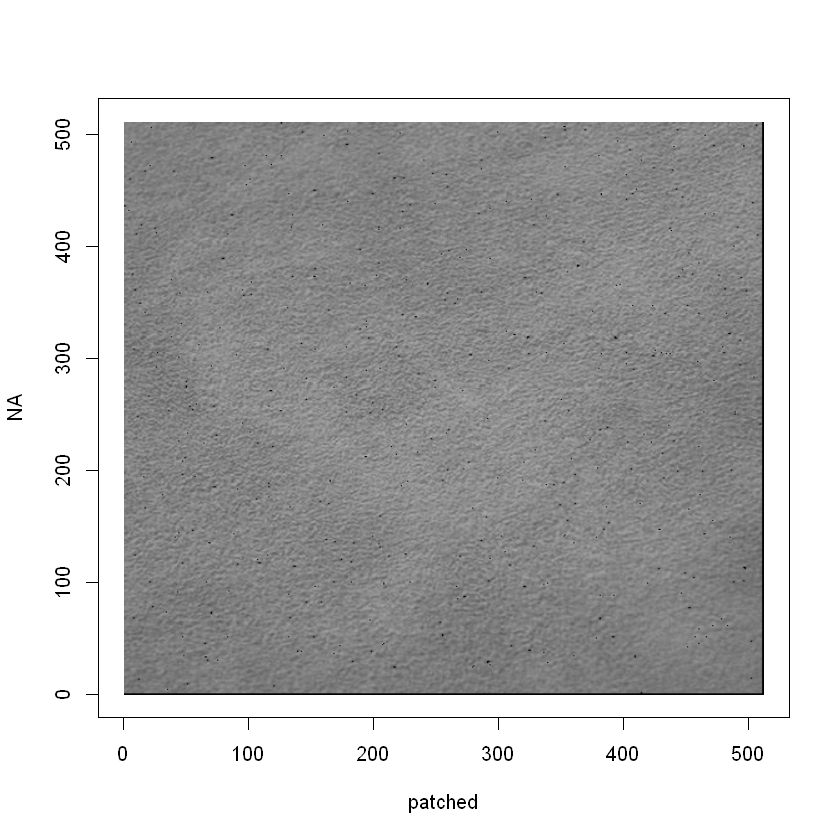

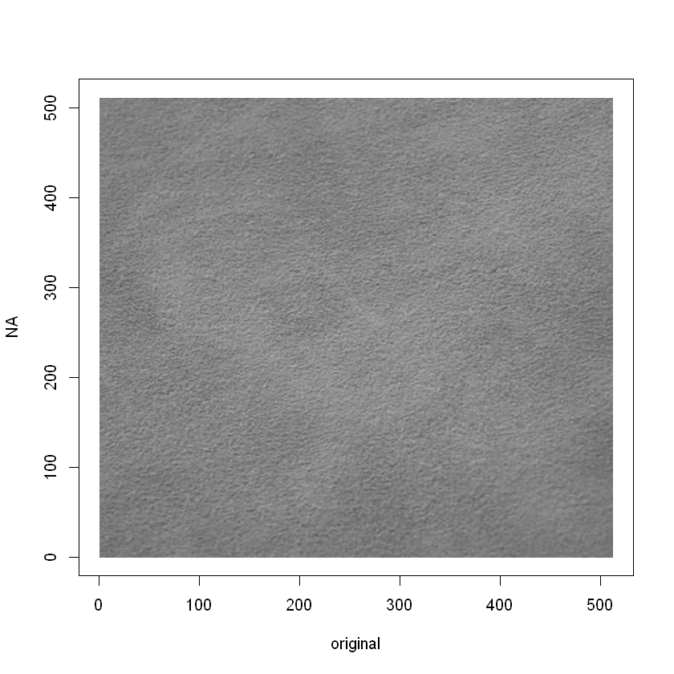

```r
par(mfrow=c(1,1))
plot(NA,xlab="patched",xlim=c(0,nrow(imgwindow)),ylim=c(0,ncol(imgwindow)))
rasterImage(imgwindow,0,0,nrow(imgwindow),ncol(imgwindow))
plot(NA,xlab="original",xlim=c(0,nrow(imgdata)),ylim=c(0,ncol(imgdata)))
rasterImage(imggray,0,0,nrow(imgdata),ncol(imgdata))
```

We displayed the updated (batched) image and the original image.

The same operation as in the 3rd question applies here with a little difference. Now, the outlier whitest and blackest pixels in each patch were converted to pure black pixels. However, compared to 3rd question, the distribution of the new pure black dots are completely different now. For instance, we see several black dot clusters in 3rd question, but here they are more systematicly distributed along the image and we see no black dot clusters. Besides, like in the 3rd question, original and updated (batched) images are quite different. Newly created black pixels can be seen easily.

### [Here](https://github.com/BU-IE-582/fall19-berkaykocakk/blob/master/files/IE423ProjectFirstSubmission.ipynb) is the source code.